# DATA100 Introduction to Data Analytics

Lecture: Data Visualization Principles

Agassi Iu

Wilfrid Laurier University

2026-09-29

## Where these principles come from

Not arbitrary style preferences, mostly grounded in research on how humans actually perceive and compare visual information.

**Note**

The preferred visualization choices are the ones that best match how our brains process shapes, lengths, and positions, not just what looks nice.

**Keep your goal in mind**

A plot for yourself during exploration will look different from a plot built to communicate a finding to an audience.

# Encoding data with visual cues

## Not all visual cues are equal

Several visual channels are available to represent a value: position, length, angle, area, brightness, colour hue.

**Human’s perception**

We are quite good at comparing **position and length**. We are noticeably worse at judging **angles**, and even worse at judging **area** alone. Brightness and colour hue are the hardest of all to quantify precisely.

## Can you read pie charts?

A pie chart encodes each value with **both** angle and area simultaneously.

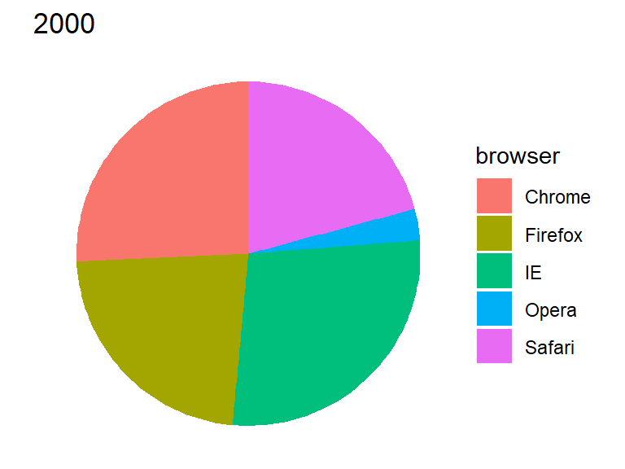

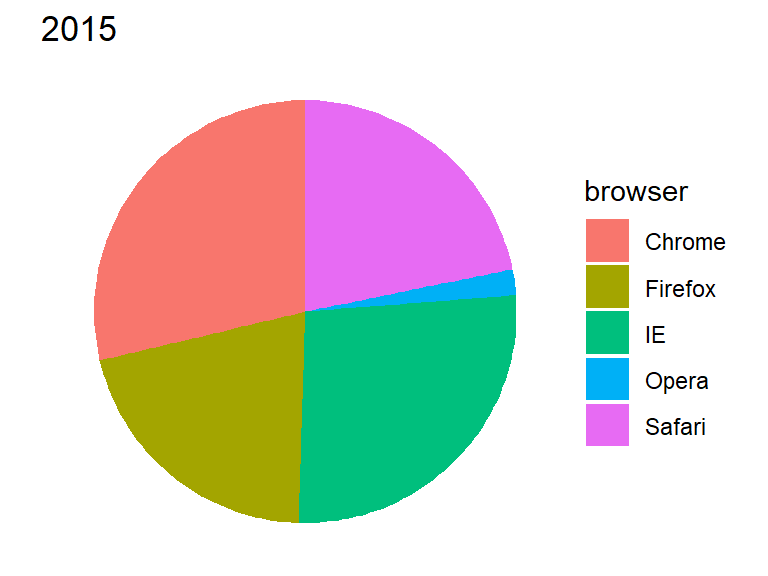

```r
ggplot(browsers |> filter(year == "2000"), aes(x = "", y = pct, fill = browser)) +
  geom_col(width = 1) + coord_polar("y") +
  labs(title = "2000", x = NULL, y = NULL) + theme_void()
ggplot(browsers |> filter(year == "2015"), aes(x = "", y = pct, fill = browser)) +
  geom_col(width = 1) + coord_polar("y") +
  labs(title = "2015", x = NULL, y = NULL) + theme_void()
```

## What about bar plots?

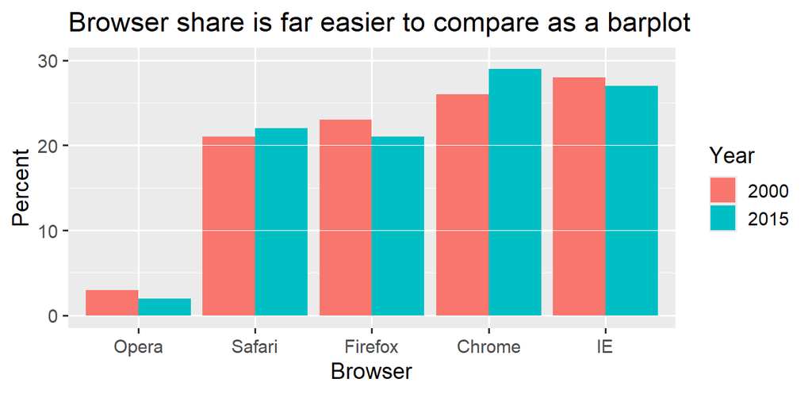

```r
ggplot(browsers, aes(x = fct_reorder(browser, pct, .fun = mean), y = pct, fill = year)) +
  geom_col(position = "dodge") +
  geom_hline(yintercept = seq(0, 30, 10), color = "white", linewidth = 0.3) +
  labs(x = "Browser", y = "Percent", fill = "Year",
       title = "Browser share is far easier to compare as a barplot")
```

## Exercise

**Which browser grew the most from 2000 to 2015?**

# Know when to include 0

## Length implies proportionality

- When a visual cue is **length** (as in a bar plot), the reader assumes the length is proportional to the value.
- If the bar doesn’t start at 0, that assumption breaks and a small real difference can be stretched to look huge.

**Common problem in media**

This is a favourite trick of misleading charts in the media: truncate the y-axis, and a 16% increase can be made to look like it nearly tripled.

## Exaggerated axis truncation

[figure not shown]

## How to exaggerate an increase?

**Try playing around with the axis**

## Length vs Position

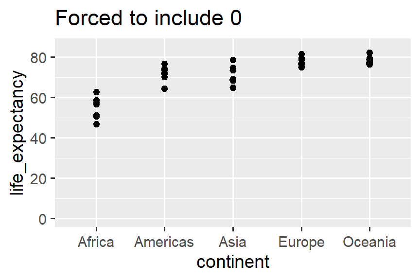

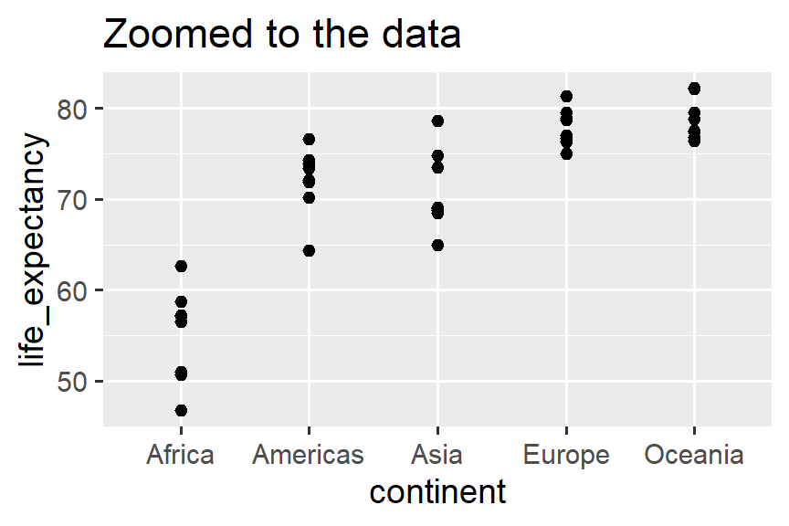

```r
ggplot(life_exp, aes(x = continent, y = life_expectancy)) +
  geom_point() +
  coord_cartesian(ylim = c(0, 85)) +
  labs(title = "Forced to include 0")
ggplot(life_exp, aes(x = continent, y = life_expectancy)) +
  geom_point() +
  labs(title = "Zoomed to the data")
```

## The rule of thumb

**Is the 0 required here?**

The empty space between 0 and 50 in the left plot adds no information and makes it harder to see the within-group and between-group variability that actually matters here.

**Bars vs Points**

If length is your visual cue (bars), **always** include 0. If position is your cue (points, lines), it’s fine (often better) to zoom to the range that matters.

# Do not distort quantities

## Circles

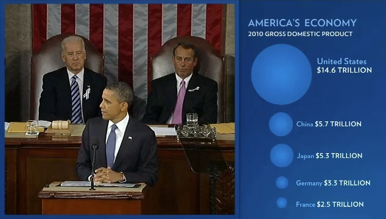

## Radius-proportional vs. area-proportional

**Tip**

`ggplot2`’s `scale_size_area()` defaults to making **area**, not radius, proportional to the value — the mathematically honest choice. Worth knowing which default you’re getting when you map a value to `size`.

## Just use a different plot!

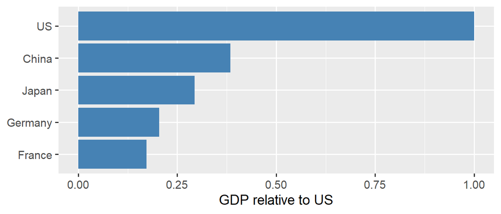

```r
ggplot(gdp, aes(x = fct_reorder(country, ratio), y = ratio)) +
  geom_col(fill = "steelblue") +
  coord_flip() +
  labs(x = NULL, y = "GDP relative to US")
```

# Show the data

## Oh Hello?

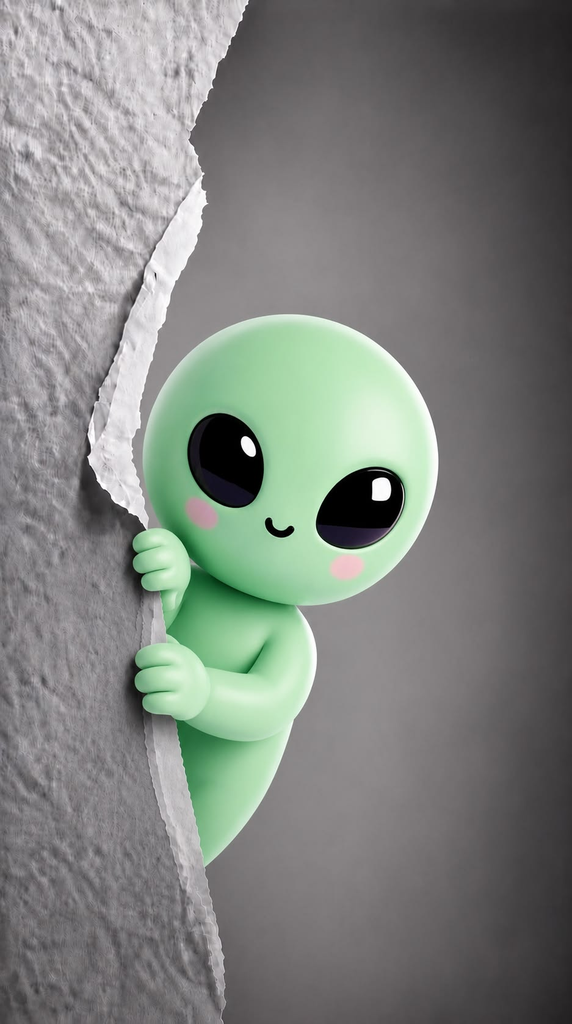

## Meet ET

**How tall are you humans?**

The extra-terrestrial arrives Earth for the first time. Instead of asking if you have any mass destructive weapons or asking for the most inappropriate curses words in human language, the alien asks you: How tall are you guys?

**Uh-oh, what do I do?**

## The Antennae plot

Imagine describing human height to an alien who has never seen a person. A common way to compare two groups (popularized by spreadsheet software) is the **dynamite plot**: a bar at the group mean, with error-bar “antennae”.

```r
heights |>
  group_by(sex) |>
  summarize(mean = mean(height), se = sd(height) / sqrt(n())) |>
  ggplot(aes(x = sex, y = mean)) +
  geom_col(fill = "grey70", width = 0.6) +
  geom_errorbar(aes(ymin = mean, ymax = mean + 2 * se), width = 0.2) +
  labs(y = "Height (in)")
```

## Bar going to 0 means 0-in height?

[figure not shown]

## Can you see the shape of the crowd?

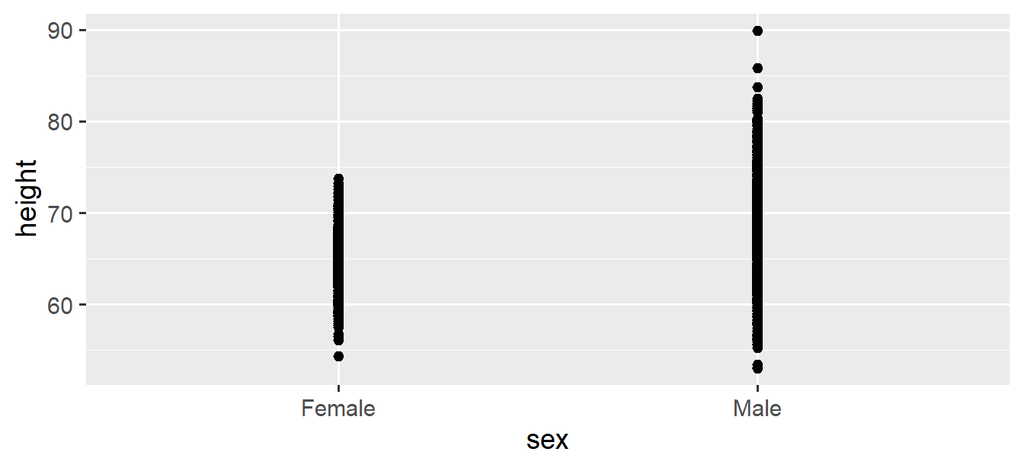

```r
ggplot(heights, aes(x = sex, y = height)) +
  geom_point()
```

## Jitter and alpha blending

Two small fixes make an enormous difference when points overlap heavily:

**Jitter**

`geom_jitter(...)` adds a small random horizontal nudge to each point, spreading out ones that would otherwise land exactly on top of each other.

- `geom_jitter(width=...)` adjusts the amount of horizontal jitter.

**Alpha**

Does anyone recall what does `alpha` change to a plot?

- makes points semi-transparent, so denser regions naturally look darker.

# Jitter and Alpha

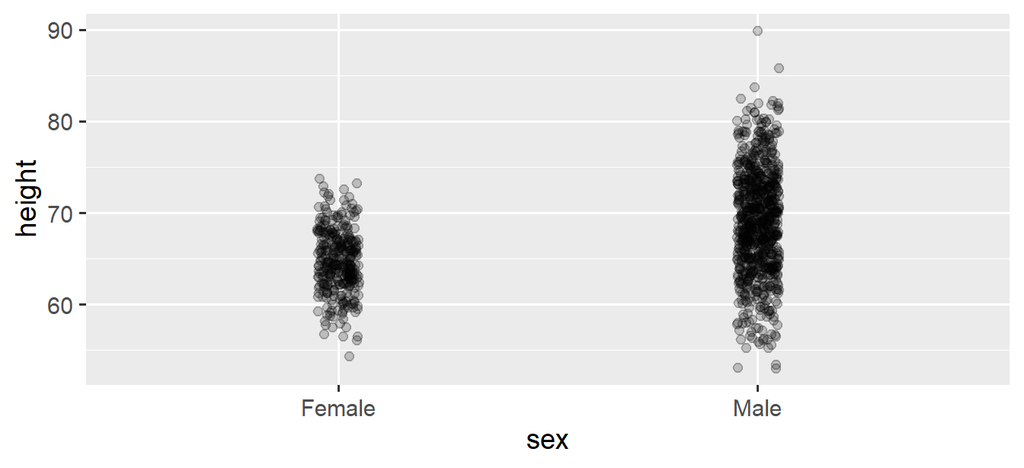

```r
ggplot(heights, aes(x = sex, y = height)) +
  geom_jitter(width = 0.05, alpha = 0.2)
```

Now the height difference between groups, and the overall shape of each distribution, are both visible at a glance.

## Exercise

**Tip**

# Ease comparisons

## Are the men taller than women?

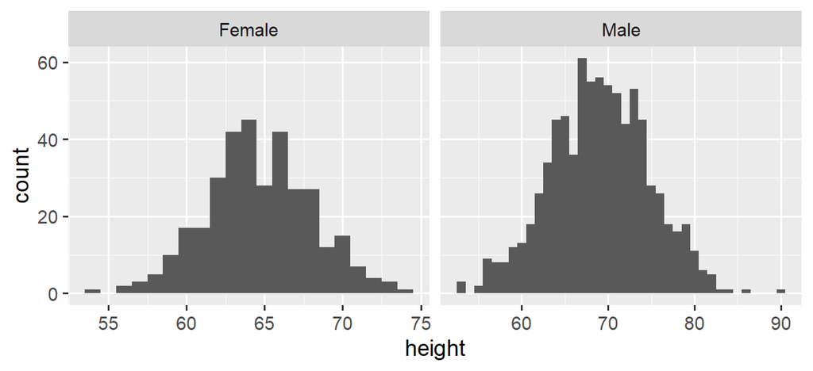

```r
ggplot(heights, aes(x = height)) +
  geom_histogram(binwidth = 1) +
  facet_wrap(~sex, scales = "free_x")
```

## Same data, Same Binwidth

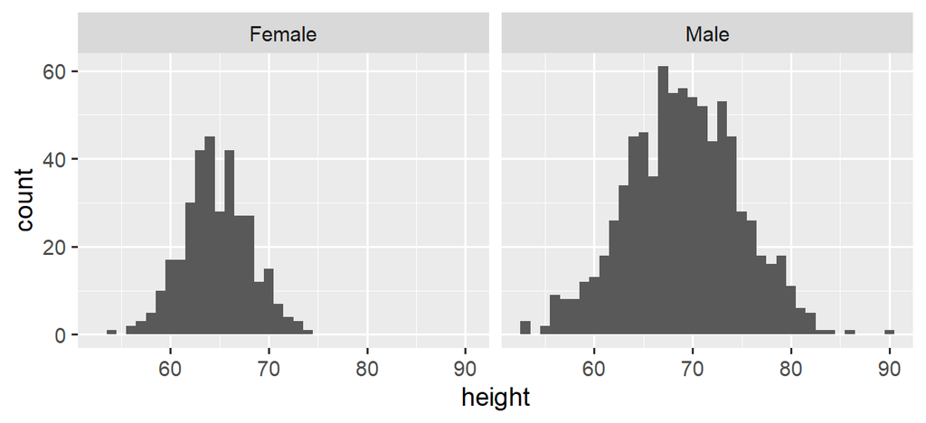

```r
ggplot(heights, aes(x = height)) +
  geom_histogram(binwidth = 1) +
  facet_wrap(~sex)
```

## Aligning plots

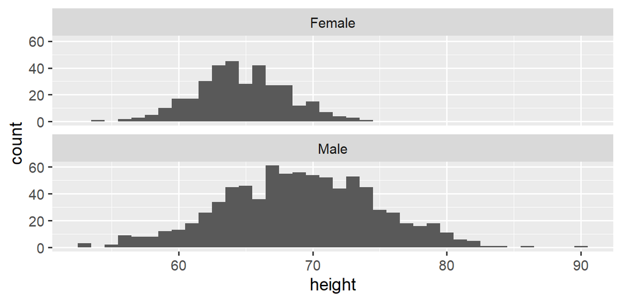

```r
ggplot(heights, aes(x = height)) +
  geom_histogram(binwidth = 1) +
  facet_wrap(~sex, ncol = 1)
```

## Align the other way

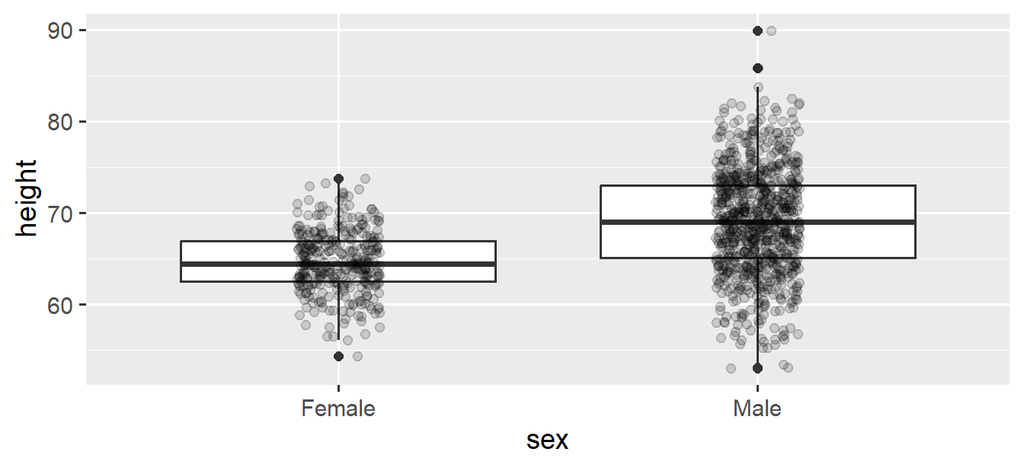

```r
ggplot(heights, aes(x = sex, y = height)) +
  geom_boxplot() +
  geom_jitter(width = 0.1, alpha = 0.15)
```

## Three plots, one dataset

**Which plot is better?**

## Summary

- **Position and length** are the visual cues humans read most accurately; angle is worse, area worse still, colour/brightness hardest of all
- **Always include 0** when the cue is length (bars); it’s optional, often better skipped, when the cue is position (poi`nts)
- **Radius ≠ area**: squaring a linear scale factor silently exaggerates differences
- **Show the data**: raw points, jitter, and alpha blending beat a bar + error bar summary almost every time
- **Match the axes and align your panels** to the direction of the comparison you actually want the reader to make

# Visualization and Midterm Review on Thursday